# Exploring the BRFSS data

Bugra Sebati Erdogan

27 12 2020

## Setup

### Load packages

```r
library(ggplot2)
library(dplyr)
```

### Load data

```r
load("brfss2013.RData")
```

## Part 1: Data

Generabizability: Data can only be generalized to those 18 years of age and older who are members of a household with a telephone. That is, it cannot be generalized to all locations, as access to telephones isn’t equal worldwide.

Causality: It’s not possible to establish a causal relationship, since the data are claims of an observation, not an experiment. So the most we can do is find some kind of correlation.

## Part 2: Research questions

**Research question 1:** Is there any correlation between Number Of Children In Household (children) and how long you sleep (sleptim1)? How does this vary by gender (sex)?

**Research question 2:** Does How Many Hours Per Week Did You Work (scntlwk1) affect How Much Time Do You Sleep (sleptim1)? How this affect Difficulty Concentrating Or Remembering (decide)?

**Research question 3:** Is there any relation between How Many Days Depressed In Past 30 Days (qlmentl2) and Avg Alcoholic Drinks Per Day In Past 30 (avedrnk2), based on how many times Exercised In Past 30 Days (exerany2)?

## Part 3: Exploratory data analysis

**Research quesion 1:**

```r
question_1 <- select(brfss2013, children, sleptim1, sex) %>% filter(children != "NA") %>% filter(sleptim1 != "NA") %>% filter(sex != "NA")
summary(question_1)
```

```
##     children          sleptim1          sex
##  Min.   : 0.0000   Min.   : 1.000   Male  :197974
##  1st Qu.: 0.0000   1st Qu.: 6.000   Female:284261
##  Median : 0.0000   Median : 7.000
##  Mean   : 0.5201   Mean   : 7.051
##  3rd Qu.: 1.0000   3rd Qu.: 8.000
##  Max.   :24.0000   Max.   :24.000
```

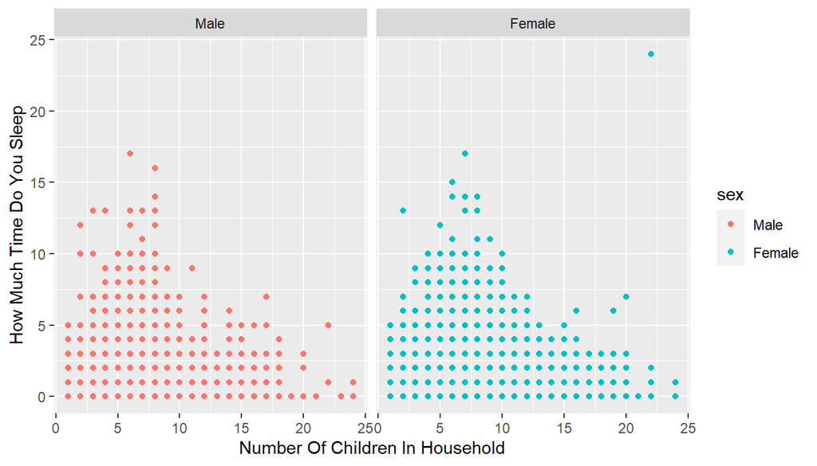

```r
plot_1 <- ggplot(question_1, aes(sleptim1, children))
plot_1 + geom_point(aes(colour = sex)) + facet_grid(.~sex) + xlab("Number Of Children In Household") + ylab("How Much Time Do You Sleep")
```

**Research quesion 2:**

```r
question_2 <- select(brfss2013, scntlwk1, sleptim1, decide) %>% filter(scntlwk1 != "NA") %>% filter(sleptim1 != "NA") %>% filter(decide != "NA")
summary(question_2)
```

```
##     scntlwk1        sleptim1     decide
##  Min.   : 0.00   Min.   : 1.00   Yes: 2176
##  1st Qu.:40.00   1st Qu.: 6.00   No :18602
##  Median :40.00   Median : 7.00
##  Mean   :42.01   Mean   : 7.28
##  3rd Qu.:48.00   3rd Qu.: 8.00
##  Max.   :98.00   Max.   :24.00
```

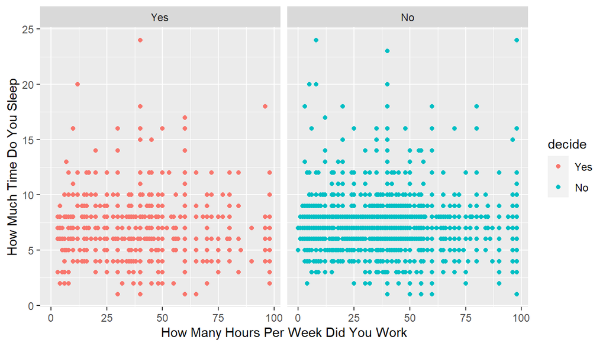

```r
plot_2 <- ggplot(question_2, aes(scntlwk1, sleptim1))
plot_2 + geom_point(aes(colour = decide)) + facet_grid(.~decide) + xlab("How Many Hours Per Week Did You Work") + ylab("How Much Time Do You Sleep")
```

It seems that there is no difference between those with difficulty remembering or concentrating.The format of the graphics is very similar.

**Research quesion 3:**

```r
question_3 <- select(brfss2013, qlmentl2, avedrnk2, exerany2) %>% filter(qlmentl2 != "NA") %>% filter(avedrnk2 != "NA") %>% filter(exerany2 != "NA")
summary(question_3)
```

```
##     qlmentl2         avedrnk2      exerany2
##  Min.   : 0.000   Min.   : 1.000   Yes:115
##  1st Qu.: 0.000   1st Qu.: 1.000   No : 46
##  Median : 0.000   Median : 2.000
##  Mean   : 3.807   Mean   : 2.584
##  3rd Qu.: 3.000   3rd Qu.: 3.000
##  Max.   :30.000   Max.   :20.000
```

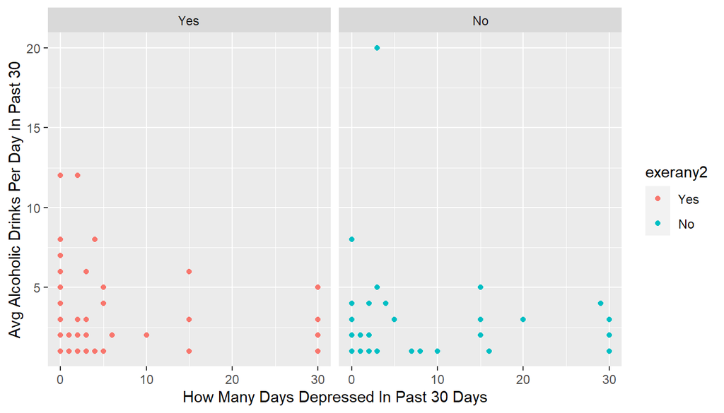

```r
plot_3 <- ggplot(question_3, aes(qlmentl2, avedrnk2))
plot_3 + geom_point(aes(colour = exerany2)) + facet_grid(.~exerany2) + xlab("How Many Days Depressed In Past 30 Days") + ylab("Avg Alcoholic Drinks Per Day In Past 30")
```

According to the chart, people who have not exercised tend to have a little more days feeling depressed. In addition, there is also a slight correlation between drinking and feeling depressed: people who drink more tend to have less depressed days.